# STAT-462: Lab 4

Candace Todd

March 3, 2021

# 1 Markdown

```r
# Clear workspace
rm(list=ls())

# Load libraries
library(ggplot2)
library(ggpubr)
library(Stat2Data)
library(corrplot)
library(olsrr)
library(sf)
library(tmap)
library(readxl)
library(plotly)
library(tidyverse)
library(skimr)
library(hrbrthemes)
```

# 2 Public Safety

There are 2 columns in this data set.

```r
spending <- read_excel("expenditure.xlsx")
print(paste("Number of Columns: ", ncol(spending), sep=""))
```

```
## [1] "Number of Columns: 2"
```

## 2.1 - Q1

The purpose of this simulated data set is to examine the relationship between town population and public safety spending for 29 suburban towns in some metropolitan area. The 2 variables in the data set are `TownPop`, the town’s population in tens of thousands, and `Expenditure`, per-capita public spending safety (I’m assuming in units of US dollars per person). Each of the 29 rows represents one town’s population and per-capita public safety spending. We want to inspect population as a predictor of spending. Assuming these data were randomly selected we can extend our following conclusions to the whole metropolitan area from which the data were gathered (all in theory, since these are simulated data).

It is possible that there are money-related confounding variables, such as the income for the town citizens or house prices for the town. Both of these impact the amount of taxes people pay, which is directly related to local public spending budgets. We briefly discussed in class that people with higher incomes have a higher spread in the amount of money they spend on food, perhaps this phenomenon also presents itself with other need-based expenses like public safety. It seems that population density in the town, which is also related to income and house prices since less-wealthy people living in suburban areas live in denser neighborhoods, is also a possible confounding variable.

The average town population is 351,900 people with a standard deviation of 129,800 people. The average per-capita public safety expenditure is $140.78 per person with a standard deviation of $37.59 per person. We see that both variables are positively skewed, but `Expenditure` has a larger spread and greater skew than `TownPop`.

*(Note: Scales on axes below are different)*

```r
skim(spending) # Examine vairables
```

Data summary

| Name | spending |
| --- | --- |
| Number of rows | 29 |
| Number of columns | 2 |
| _______________________ |  |
| Column type frequency: |  |
| numeric | 2 |
| ________________________ |  |
| Group variables | None |

**Variable type: numeric**

| skim_variable | n_missing | complete_rate | mean | sd | p0 | p25 | p50 | p75 | p100 | hist |
| --- | --- | --- | --- | --- | --- | --- | --- | --- | --- | --- |
| TownPop | 0 | 1 | 35.19 | 12.98 | 14 | 28 | 32 | 40 | 76 | ▃▇▃▁▁ |
| Expenditure | 0 | 1 | 140.78 | 37.59 | 70 | 135 | 138 | 142 | 310 | ▁▇▁▁▁ |

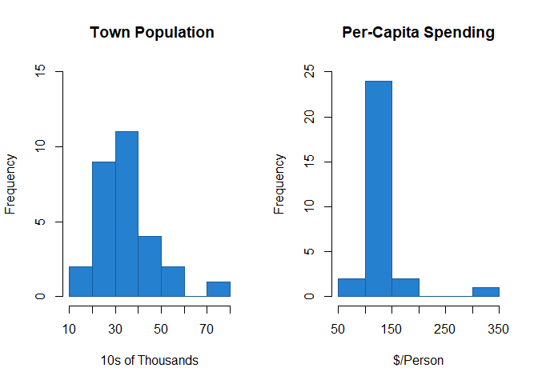

```r
spending <- arrange(spending, desc(Expenditure)) # Sort by expenditure

# Plot histograms of both variables
par(mfrow=c(1,2))
hist(spending$TownPop, col="#2680D0", border="#1A5C96", main=" Town Population", xlab="10s of Thousands", ylim=c(0,15))
hist(spending$Expenditure, col="#2680D0", border="#1A5C96", main= "Per-Capita Spending", xlab="$/Person", ylim=c(0,25))
```

*(Note: Scales on axes below are different)*

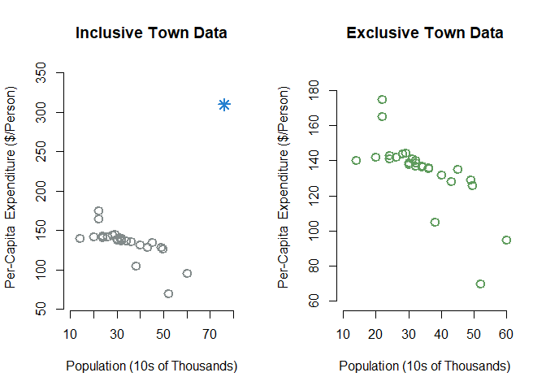

```r
outlier <- spending[1,] # Extract the outlier, the one with the highest of both values

# Plotting data with and without outlier side by side
par(mfrow=c(1,2))

# Plot all data, but initally exclude the outlier
plot(x=spending[-1,]$TownPop, # outlier is in the first row because we sorted
     y=spending[-1,]$Expenditure,
     cex=1.5,       # point size
     lwd=2,         # line thickness
     frame=FALSE,   # remove plot frame
     xlim=c(10,80),  # set x axis limits
     ylim=c(60,350), # set y axis limits
     xlab="Population (10s of Thousands)",      # x-axis label
     ylab="Per-Capita  Expenditure ($/Person)", # y-axis label
     col="azure4",                              # point color
     main="Inclusive Town Data")                # plot title

# Now plot just outlier
lines(outlier$TownPop, outlier$Expenditure, col="#2680D0", type="p", pch=8, cex=1.5, lwd=2)

# Plot all data without the outlier at all
plot(x=spending[-1,]$TownPop, y=spending[-1,]$Expenditure, cex=1.5, lwd=2, frame=FALSE, xlim=c(10,60), ylim=c(60,190), xlab="Population (10s of Thousands)", ylab="Per-Capita  Expenditure ($/Person)", main="Exclusive Town Data", col="#5F9C5D")
```

## 2.2 - Q2

If the taxpayers’ claim that smaller towns spend more on public safety per person is true, we should see a negative slope in our simple linear regression line— as we would observe higher town populations, we would observe lower per-capita spending $\iff$ we would observe higher per-capita public safety spending in towns with lower populations.

## 2.3 - Q3

Performing a simple linear regression on the inclusive data gives us the equation

$$\widehat{\text{Per-Capita Spending}}=117.6143 + 0.6584\times( \frac{\text{Population}}{10,000})$$

where $\text{Per-Capita Spending}$ is in dollars spent on public safety per person (assumed units) in that town and $\text{Population}$ is the number of people in a town. In our equation we divide population by 10,000 because the population units used for the model were in tens of thousands. This regression equation has a positive slope, which is the opposite of what the taxpayers claimed would be true. But the p-value for our slope is $p=0.236>0.05=\alpha$ meaning we do not have a statistically significant amount of evidence to suggest that the true slope for the line relating this municipality’s towns’ populations to their expenditures is non-zero. From this analysis we see that it is possible that there is truly no linear relationship between the two variables.

However, when we were looking back at our scatterplots from **Q1** we saw that the outlier distorted the apparent relationship between population and spending that seemed to be present when we focused on the rest of the data. Further consideration of the outlier should be done before making any formal conclusions about the slope.

```r
model1 <- lm(Expenditure~TownPop, spending)
summary(model1)
```

```
##
## Call:
## lm(formula = Expenditure ~ TownPop, data = spending)
##
## Residuals:
##     Min      1Q  Median      3Q     Max
## -81.850 -11.950   0.317   7.792 142.348
##
## Coefficients:
##             Estimate Std. Error t value Pr(>|t|)
## (Intercept) 117.6143    20.3181   5.789  3.7e-06 ***
## TownPop       0.6584     0.5428   1.213    0.236
## ---
## Signif. codes:  0 '***' 0.001 '**' 0.01 '*' 0.05 '.' 0.1 ' ' 1
##
## Residual standard error: 37.28 on 27 degrees of freedom
## Multiple R-squared:  0.05167,    Adjusted R-squared:  0.01654
## F-statistic: 1.471 on 1 and 27 DF,  p-value: 0.2357
```

## 2.4 - Q4

Below we plot the inclusive data and the corresponding regression line with its confidence interval.

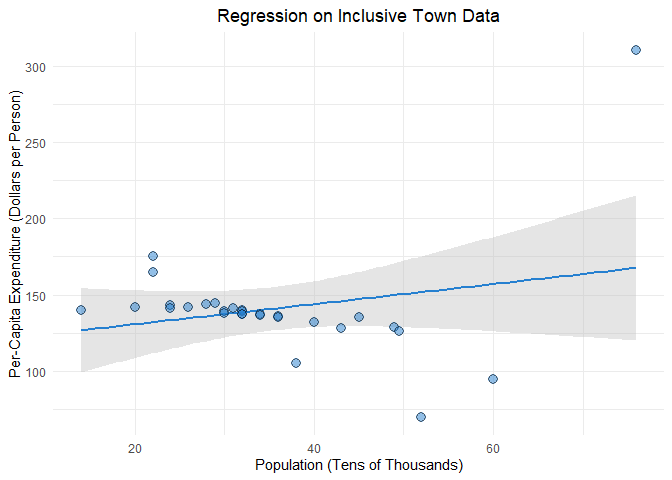

```r
# Plot data with regression line
ggplot(data=spending, mapping=aes(x=TownPop, y=Expenditure)) +        # Set attributes for whole plot
  geom_smooth(method=lm, color="#2680D0", fill="grey", formula=y~x) + # Set attributes for linear model layer
  geom_point(shape=21, stroke=1,fill="#2680D0", size=3, alpha=0.5) +  # Set attributes for scatterplot layer
  theme_minimal() + # Set plot color scheme
  xlab("Population (Tens of Thousands)") +              # Set x-axis label
  ylab("Per-Capita Expenditure (Dollars per Person)") + # Set y-axis label
  ggtitle("Regression on Inclusive Town Data") +        # Set title
  theme(plot.title = element_text(hjust = 0.5))         # Center title
```

## 2.5 - Q5

To our eyes, most of the points in the scatterplot above seem to be following a downward trend, but the regression line is sloping upward. It doesn’t look like the regression line is fitting the data well, which would mean the regression line is misleading as a “line of best fit”. This regression line does not seem to be following the same underlying trend as the majority of the data.

## 2.6 - Q6

When we remove the outlier, the linear regression yields a negative slope with a low p-value $p\approx 0.000006 < 0.05=\alpha$. Without the outlier there is strong evidence to suggest that our slope is non-zero. Now the “line of best fit” follows the data in a way that is consistent with what our eyes intuitively see as a good fit. Also, since this slope is negative, this regression output gives evidence to support the taxpayers’ claim that towns with higher populations have less per-capita expenditures.

```r
# Removing the outlier
# Our data is sorted, so the outlier will be in the first row
spending.new <- spending[-1,]

# Get a new linear model from the data that doesn't include the outlier
model2 <- lm(Expenditure~TownPop, spending.new)
summary(model2)
```

```
##
## Call:
## lm(formula = Expenditure ~ TownPop, data = spending.new)
##
## Residuals:
##     Min      1Q  Median      3Q     Max
## -40.022  -3.450   2.020   4.682  24.386
##
## Coefficients:
##             Estimate Std. Error t value Pr(>|t|)
## (Intercept) 180.3812     8.4243  21.412  < 2e-16 ***
## TownPop      -1.3531     0.2388  -5.667 5.84e-06 ***
## ---
## Signif. codes:  0 '***' 0.001 '**' 0.01 '*' 0.05 '.' 0.1 ' ' 1
##
## Residual standard error: 13.06 on 26 degrees of freedom
## Multiple R-squared:  0.5526, Adjusted R-squared:  0.5354
## F-statistic: 32.11 on 1 and 26 DF,  p-value: 5.844e-06
```

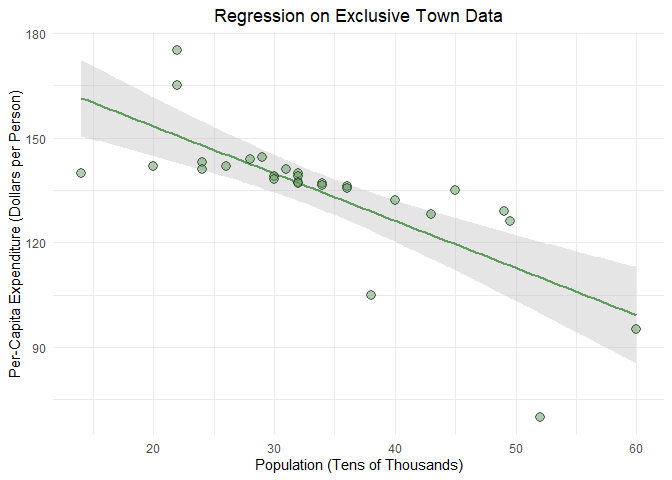

```r
# Plot the data without the outlier
ggplot(data=spending.new, mapping=aes(x=TownPop, y=Expenditure)) +
  geom_smooth(method=lm, color="#5F9C5D", fill="grey", formula=y~x) +
  geom_point(shape=21, stroke=1,fill="#5F9C5D", size=3, alpha=0.5) +
  theme_minimal() +
  xlab("Population (Tens of Thousands)") +
  ylab("Per-Capita Expenditure (Dollars per Person)") +
  ggtitle("Regression on Exclusive Town Data") +
  theme(plot.title = element_text(hjust = 0.5))
```